# projekt_2

## 1. Wstęp, prezentacja bazy danych

W projekcie badam klasyfikację muzyki na podstawie 17 cech wejściowych oraz 1 cechy wyjściowej, która określa gatunek muzyczny. W tym celu korzystam z bazy danych "Prediction of music genre" zawierającej 50 000 próbek, które są opisane następującymi kolumnami:

1. instance_id: Unikalny identyfikator dla każdej próbki w zbiorze danych, reprezentowany jako liczba zmiennoprzecinkowa.
2. artist_name: Nazwa artysty, który stworzył utwór, reprezentowana jako ciąg znaków (obiekt).
3. track_name: Nazwa utworu, reprezentowana jako ciąg znaków (obiekt).
4. popularity: Miara popularności utworu, reprezentowana jako liczba zmiennoprzecinkowa między 0 a 100.
5. acousticness: Miara akustyczności utworu, reprezentowana jako liczba zmiennoprzecinkowa między 0 a 1.
6. danceability: Miara taneczności utworu, reprezentowana jako liczba zmiennoprzecinkowa między 0 a 1.
7. duration_ms: Czas trwania utworu w milisekundach, reprezentowany jako liczba zmiennoprzecinkowa.
8. energy: Miara energii utworu, reprezentowana jako liczba zmiennoprzecinkowa między 0 a 1.
9. instrumentalness: Miara instrumentalności utworu, reprezentowana jako liczba zmiennoprzecinkowa między 0 a 1.
10. key: Tonacja w której jest wykonywany utwór, reprezentowana jako ciąg znaków (obiekt). Istnieje 12 możliwych wartości: 'C', 'C#', 'D', 'D#', 'E', 'F', 'F#', 'G', 'G#', 'A', 'A#' i 'B'.
11. liveness: Miara witalności utworu, reprezentowana jako liczba zmiennoprzecinkowa między 0 a 1.
12. loudness: Miara głośności utworu, reprezentowana jako liczba zmiennoprzecinkowa w decybelach (dB).
13. mode: Tryb, w którym jest wykonywany utwór, reprezentowany jako ciąg znaków (obiekt). Istnieją dwie możliwe wartości: 'major' i 'minor'.
14. speechiness: Miara wymowności utworu, reprezentowana jako liczba zmiennoprzecinkowa między 0 a 1.
15. tempo: Tempo utworu wyrażone w uderzeniach na minutę (BPM), reprezentowane jako ciąg znaków (obiekt).
16. obtained_date: Data, w której informacje o utworze zostały uzyskane, przedstawione jako łańcuch znaków (obiekt).
17. valence: Wartość wyrażająca pozytywność utworu, przedstawiona jako liczba zmiennoprzecinkowa między 0 a 1.

music_genre: Gatunek muzyczny utworu, przedstawiony jako łańcuch znaków (obiekt). Możliwe gatunki w zestawie danych to: 'Electronic', 'Anime', 'Jazz', 'Alternative', 'Country', 'Rap', 'Blues', 'Rock', 'Classical', 'Hip-Hop'.

## 2. Preprocessing

##### 2.1 Importowanie niezbędnych bibliotek

```python
import numpy as np
import pandas as pd
import matplotlib.pyplot as plt
from sklearn.preprocessing import LabelEncoder
from sklearn.model_selection import train_test_split
from sklearn.preprocessing import StandardScaler
from sklearn.decomposition import PCA
from sklearn.tree import DecisionTreeClassifier
from sklearn.metrics import accuracy_score
from sklearn.metrics import confusion_matrix
from sklearn.naive_bayes import GaussianNB
from sklearn.neighbors import KNeighborsClassifier
from keras import Sequential
from keras.layers import Dense
import tabulate
```

##### 2.2 Atrybuty bazy danych

```python
data = pd.read_csv("/projekt_2/music_genre.csv")
data.head()
```

|  | instance_id | artist_name | track_name | popularity | acousticness | danceability | duration_ms | energy | instrumentalness | key | liveness | loudness | mode | speechiness | tempo | obtained_date | valence | music_genre |
| --- | --- | --- | --- | --- | --- | --- | --- | --- | --- | --- | --- | --- | --- | --- | --- | --- | --- | --- |
| 0 | 32894.0 | Röyksopp | Röyksopp's Night Out | 27.0 | 0.00468 | 0.652 | -1.0 | 0.941 | 0.79200 | A# | 0.115 | -5.201 | Minor | 0.0748 | 100.889 | 4-Apr | 0.759 | Electronic |
| 1 | 46652.0 | Thievery Corporation | The Shining Path | 31.0 | 0.01270 | 0.622 | 218293.0 | 0.890 | 0.95000 | D | 0.124 | -7.043 | Minor | 0.0300 | 115.00200000000001 | 4-Apr | 0.531 | Electronic |
| 2 | 30097.0 | Dillon Francis | Hurricane | 28.0 | 0.00306 | 0.620 | 215613.0 | 0.755 | 0.01180 | G# | 0.534 | -4.617 | Major | 0.0345 | 127.994 | 4-Apr | 0.333 | Electronic |
| 3 | 62177.0 | Dubloadz | Nitro | 34.0 | 0.02540 | 0.774 | 166875.0 | 0.700 | 0.00253 | C# | 0.157 | -4.498 | Major | 0.2390 | 128.014 | 4-Apr | 0.270 | Electronic |
| 4 | 24907.0 | What So Not | Divide & Conquer | 32.0 | 0.00465 | 0.638 | 222369.0 | 0.587 | 0.90900 | F# | 0.157 | -6.266 | Major | 0.0413 | 145.036 | 4-Apr | 0.323 | Electronic |

```python
data.music_genre.value_counts()
```

```
Electronic     5000
Anime          5000
Jazz           5000
Alternative    5000
Country        5000
Rap            5000
Blues          5000
Rock           5000
Classical      5000
Hip-Hop        5000
Name: music_genre, dtype: int64
```

```python
data.info()
```

```
<class 'pandas.core.frame.DataFrame'>
RangeIndex: 50005 entries, 0 to 50004
Data columns (total 18 columns):
 #   Column            Non-Null Count  Dtype
---  ------            --------------  -----
 0   instance_id       50000 non-null  float64
 1   artist_name       50000 non-null  object
 2   track_name        50000 non-null  object
 3   popularity        50000 non-null  float64
 4   acousticness      50000 non-null  float64
 5   danceability      50000 non-null  float64
 6   duration_ms       50000 non-null  float64
 7   energy            50000 non-null  float64
 8   instrumentalness  50000 non-null  float64
 9   key               50000 non-null  object
 10  liveness          50000 non-null  float64
 11  loudness          50000 non-null  float64
 12  mode              50000 non-null  object
 13  speechiness       50000 non-null  float64
 14  tempo             50000 non-null  object
 15  obtained_date     50000 non-null  object
 16  valence           50000 non-null  float64
 17  music_genre       50000 non-null  object
dtypes: float64(11), object(7)
memory usage: 6.9+ MB
```

```python
print(f'Cechy kategoryczne: {len([x for x in data.columns if data[x].dtype == object])}')
print(f'Cechy numeryczne: {len([x for x in data.columns if data[x].dtype == float])}')
```

```
Cechy kategoryczne: 7
Cechy numeryczne: 11
```

W bazie jest 7 cech kategorycznych oraz 11 cech numerycznych, jednak tempo powinno również być wartością numeryczną, co zmienia ten stosunek do 6:12. Niektóre z próbek mają jako tempo wpisane "?", czym również się teraz zajmę, usuwając je:

```python
data.drop(data[data['tempo'] == '?'].index, inplace = True)

data["tempo"] = data["tempo"].astype(float)

print(f'Cechy kategoryczne: {len([x for x in data.columns if data[x].dtype == object])}')
print(f'Cechy numeryczne: {len([x for x in data.columns if data[x].dtype == float])}')
```

```
Cechy kategoryczne: 6
Cechy numeryczne: 12
```

##### 2.3 Histogramy poszczególnych cech

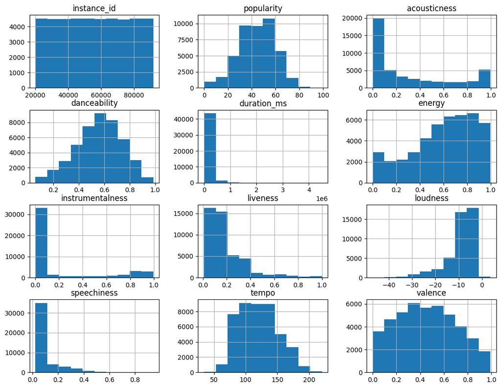

```python
fig = plt.figure(figsize = (13,10))
ax = plt.axes()
data.select_dtypes(include=np.number).hist(ax =ax)
plt.show()
```

##### 2.4 Dalsza obróbka danych

Sprawdzanie i usuwanie outlierów:

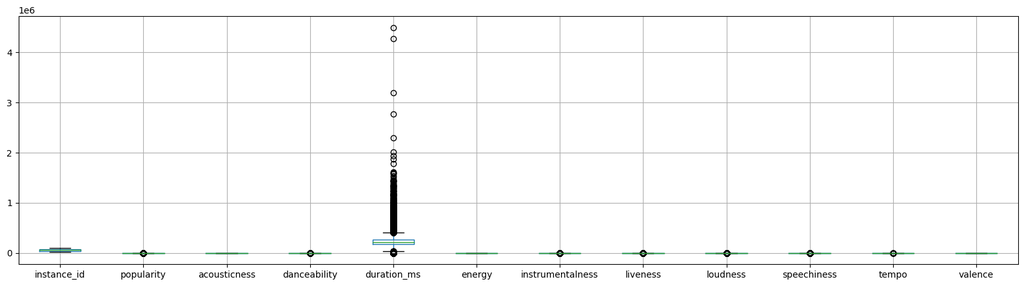

```python
plt.rcParams['figure.figsize'] = 20, 5
data.select_dtypes(include=np.number).boxplot()
```

Najwięcej outlierów jest w kategorii 'duration_ms'.

```python
upper_limit = data['duration_ms'].mean() + 3*data['duration_ms'].std()
lower_limit = data['duration_ms'].mean() - 3*data['duration_ms'].std()

print(lower_limit, upper_limit)

data[(data['duration_ms'] > upper_limit) | (data['duration_ms'] < lower_limit)]
```

```
-161895.74051548154 604234.7375834513
```

|  | instance_id | artist_name | track_name | popularity | acousticness | danceability | duration_ms | energy | instrumentalness | key | liveness | loudness | mode | speechiness | tempo | obtained_date | valence | music_genre |
| --- | --- | --- | --- | --- | --- | --- | --- | --- | --- | --- | --- | --- | --- | --- | --- | --- | --- | --- |
| 246 | 33763.0 | empty_field | Vaultage 001 | 43.0 | 0.00187 | 0.407 | 866773.0 | 0.8880 | 0.104000 | C# | 0.1720 | -3.078 | Major | 0.3330 | 123.950 | 4-Apr | 0.2930 | Electronic |
| 331 | 61573.0 | Moby | Falling Rain and Light - Glory Remix | 23.0 | 0.78900 | 0.440 | 633347.0 | 0.6440 | 0.862000 | G | 0.0985 | -9.994 | Major | 0.0479 | 104.923 | 4-Apr | 0.2810 | Electronic |
| 523 | 74073.0 | Hot Chip | Go Bang | 31.0 | 0.00745 | 0.730 | 664573.0 | 0.9120 | 0.458000 | C# | 0.2140 | -8.146 | Major | 0.0530 | 126.971 | 4-Apr | 0.7560 | Electronic |
| 614 | 87510.0 | Armen Miran | Inevitable Ending - Viken Arman & Goldcap Remix | 37.0 | 0.00161 | 0.889 | 860761.0 | 0.4800 | 0.835000 | A# | 0.0514 | -12.380 | Minor | 0.0747 | 100.002 | 4-Apr | 0.0751 | Electronic |
| 628 | 22302.0 | Underworld | Threat Of Rain | 0.0 | 0.17800 | 0.702 | 890680.0 | 0.5630 | 0.890000 | C | 0.1510 | -15.157 | Major | 0.0500 | 130.003 | 4-Apr | 0.5810 | Electronic |
| ... | ... | ... | ... | ... | ... | ... | ... | ... | ... | ... | ... | ... | ... | ... | ... | ... | ... | ... |
| 44946 | 41836.0 | Ludwig van Beethoven | Symphony No. 7 in A Major, Op. 92: 1. Poco sos... | 31.0 | 0.95700 | 0.347 | 816000.0 | 0.1730 | 0.572000 | A | 0.0950 | -17.496 | Major | 0.0394 | 107.256 | 4-Apr | 0.1130 | Classical |
| 44952 | 27147.0 | Philip Glass | Mad Rush | 42.0 | 0.98400 | 0.188 | 871267.0 | 0.0376 | 0.923000 | F | 0.0801 | -24.388 | Major | 0.0431 | 114.230 | 4-Apr | 0.0394 | Classical |
| 44974 | 76542.0 | Anton Bruckner | Symphony No. 8 in C Minor, WAB 108 (1890 editi... | 29.0 | 0.96300 | 0.197 | 1445107.0 | 0.0893 | 0.863000 | F | 0.6800 | -19.377 | Minor | 0.0391 | 112.144 | 4-Apr | 0.0379 | Classical |
| 44993 | 35853.0 | Mieczysław Weinberg | Rhapsody on Moldavian Themes Op. 47 No. 3 | 29.0 | 0.88700 | 0.294 | 647400.0 | 0.1490 | 0.036200 | F | 0.0686 | -18.557 | Major | 0.0450 | 82.696 | 4-Apr | 0.0860 | Classical |
| 46255 | 57380.0 | Kendrick Lamar | Sing About Me, I'm Dying Of Thirst | 60.0 | 0.30300 | 0.654 | 723573.0 | 0.7530 | 0.000081 | B | 0.1300 | -7.556 | Minor | 0.3950 | 110.722 | 5-Apr | 0.3710 | Hip-Hop |

427 rows × 18 columns

```python
data.drop(data[(data['duration_ms'] > upper_limit) | (data['duration_ms'] < lower_limit)].index, inplace = True)
```

Sprawdzanie i usuwanie danych o wartości null:

```python
data.isnull().sum()
```

```
instance_id         5
artist_name         5
track_name          5
popularity          5
acousticness        5
danceability        5
duration_ms         5
energy              5
instrumentalness    5
key                 5
liveness            5
loudness            5
mode                5
speechiness         5
tempo               5
obtained_date       5
valence             5
music_genre         5
dtype: int64
```

```python
data.dropna(how='any', inplace=True)
data.isnull().sum()
```

```
instance_id         0
artist_name         0
track_name          0
popularity          0
acousticness        0
danceability        0
duration_ms         0
energy              0
instrumentalness    0
key                 0
liveness            0
loudness            0
mode                0
speechiness         0
tempo               0
obtained_date       0
valence             0
music_genre         0
dtype: int64
```

Wszystkie wartości w kolumnie 'track_name' są unikalne, więc nie mają wpływu na klasyfikację i można ją usunąć.

```python
data.drop(['track_name'],axis=1,inplace=True)
data.head()
```

|  | instance_id | artist_name | popularity | acousticness | danceability | duration_ms | energy | instrumentalness | key | liveness | loudness | mode | speechiness | tempo | obtained_date | valence | music_genre |
| --- | --- | --- | --- | --- | --- | --- | --- | --- | --- | --- | --- | --- | --- | --- | --- | --- | --- |
| 0 | 32894.0 | Röyksopp | 27.0 | 0.00468 | 0.652 | -1.0 | 0.941 | 0.79200 | A# | 0.115 | -5.201 | Minor | 0.0748 | 100.889 | 4-Apr | 0.759 | Electronic |
| 1 | 46652.0 | Thievery Corporation | 31.0 | 0.01270 | 0.622 | 218293.0 | 0.890 | 0.95000 | D | 0.124 | -7.043 | Minor | 0.0300 | 115.002 | 4-Apr | 0.531 | Electronic |
| 2 | 30097.0 | Dillon Francis | 28.0 | 0.00306 | 0.620 | 215613.0 | 0.755 | 0.01180 | G# | 0.534 | -4.617 | Major | 0.0345 | 127.994 | 4-Apr | 0.333 | Electronic |
| 3 | 62177.0 | Dubloadz | 34.0 | 0.02540 | 0.774 | 166875.0 | 0.700 | 0.00253 | C# | 0.157 | -4.498 | Major | 0.2390 | 128.014 | 4-Apr | 0.270 | Electronic |
| 4 | 24907.0 | What So Not | 32.0 | 0.00465 | 0.638 | 222369.0 | 0.587 | 0.90900 | F# | 0.157 | -6.266 | Major | 0.0413 | 145.036 | 4-Apr | 0.323 | Electronic |

Kodowanie cech kategorycznych na numeryczne:

```python
from sklearn.preprocessing import LabelEncoder

le = LabelEncoder()

data['key']=le.fit_transform(data['key'])
data['mode']=le.fit_transform(data['mode'])
data['obtained_date']=le.fit_transform(data['obtained_date'])
data['artist_name'] = le.fit_transform(data['artist_name'])
data['music_genre'] = le.fit_transform(data['music_genre'])

data.head()
```

|  | instance_id | artist_name | popularity | acousticness | danceability | duration_ms | energy | instrumentalness | key | liveness | loudness | mode | speechiness | tempo | obtained_date | valence | music_genre |
| --- | --- | --- | --- | --- | --- | --- | --- | --- | --- | --- | --- | --- | --- | --- | --- | --- | --- |
| 0 | 32894.0 | 4816 | 27.0 | 0.00468 | 0.652 | -1.0 | 0.941 | 0.79200 | 1 | 0.115 | -5.201 | 1 | 0.0748 | 100.889 | 2 | 0.759 | 5 |
| 1 | 46652.0 | 5860 | 31.0 | 0.01270 | 0.622 | 218293.0 | 0.890 | 0.95000 | 5 | 0.124 | -7.043 | 1 | 0.0300 | 115.002 | 2 | 0.531 | 5 |
| 2 | 30097.0 | 1525 | 28.0 | 0.00306 | 0.620 | 215613.0 | 0.755 | 0.01180 | 11 | 0.534 | -4.617 | 0 | 0.0345 | 127.994 | 2 | 0.333 | 5 |
| 3 | 62177.0 | 1636 | 34.0 | 0.02540 | 0.774 | 166875.0 | 0.700 | 0.00253 | 4 | 0.157 | -4.498 | 0 | 0.2390 | 128.014 | 2 | 0.270 | 5 |
| 4 | 24907.0 | 6248 | 32.0 | 0.00465 | 0.638 | 222369.0 | 0.587 | 0.90900 | 9 | 0.157 | -6.266 | 0 | 0.0413 | 145.036 | 2 | 0.323 | 5 |

Pierwszy, mniej przetworzony zbiór danych zostanie w obecnym stanie, na drugim przeprowadzam jeszcze standaryzację oraz PCA.

```python
data.music_genre.value_counts()
```

```
9    4555
6    4519
8    4504
0    4492
1    4486
4    4486
7    4474
5    4442
2    4428
3    4207
Name: music_genre, dtype: int64
```

```python
data1 = data.copy()
data2 = data.copy()

x = data.drop(['music_genre'], axis=1)
y = data['music_genre']

x1_train, x1_test, y1_train, y1_test = train_test_split(x, y, test_size = 0.3, random_state = 13)
x2_train, x2_test, y2_train, y2_test = train_test_split(x, y, test_size = 0.3, random_state = 13)

sc = StandardScaler()

x2_train = sc.fit_transform(x2_train)
x2_test = sc.transform(x2_test)

pca = PCA(n_components = 2)

x2_train = pca.fit_transform(x2_train)
x2_test = pca.transform(x2_test)

acc1 = []
acc2 = []
```

## 3. Klasyfikacja danych

##### 3.1 Przycięte drzewo decyzyjne

```python
# Mniej przetworzony zbiór
clf = DecisionTreeClassifier(criterion='entropy', max_depth=5)
clf.fit(x1_train, y1_train)
y1_pred = clf.predict(x1_test)
accuracy = accuracy_score(y1_test, y1_pred)
print("Dokładność 1: {:.2f}".format(accuracy))
print(confusion_matrix(y1_test, y1_pred))
acc1.append(accuracy)

print("\n")

# Bardziej przetworzony zbiór
clf = DecisionTreeClassifier(criterion='entropy', max_depth=5)
clf.fit(x2_train, y2_train)
y2_pred = clf.predict(x2_test)
accuracy = accuracy_score(y2_test, y2_pred)
print("Dokładność 2: {:.2f}".format(accuracy))
print(confusion_matrix(y2_test, y2_pred))
acc2.append(accuracy)
```

```
Dokładność 1: 0.44
[[313   1  75   5 424  63 109  29  80 261]
 [ 92 606 316 106  77 144   0  39   0   9]
 [ 75  83 418  25 295 325  16  72   5  49]
 [ 36  36  76 915  25  63   0 100   0  20]
 [134   0  22   2 779  34  12  47  39 252]
 [139  35 210   5  87 661  31  36  23  56]
 [ 26   1   1   0  69   8 359   7 796 108]
 [ 94  17 166 101 265 396  32 180  27  78]
 [ 17   1   2   0  49   1 253   5 787 209]
 [ 56   0   5   4 176   4  53   7 110 921]]


Dokładność 2: 0.31
[[   0  236    0    2  277  117  257  222    0  249]
 [   0  576    0  246  150  179   12  150    0   76]
 [   0  299    0   21  198  209   91  440    0  105]
 [   0   88    0 1034   18   26    1  101    0    3]
 [   0  120    0    1  254  166  176  361    0  243]
 [   0  271    0   24  199  212  142  248    0  187]
 [   0    9    0    0   45    8 1020   93    0  200]
 [   0   87    0  121   57  135  187  681    0   88]
 [   0   25    0    0   71   18  912   90    0  208]
 [   0  108    0    6  227  110  310  259    0  316]]
```

##### 3.2 Pełne drzewo decyzyjne

```python
# Mniej przetworzony zbiór
clf = DecisionTreeClassifier(criterion='entropy')
clf.fit(x1_train, y1_train)
y1_pred = clf.predict(x1_test)
accuracy = accuracy_score(y1_test, y1_pred)
print("Dokładność 1: {:.2f}".format(accuracy))
print(confusion_matrix(y1_test, y1_pred))
acc1.append(accuracy)

print("\n")

# Bardziej przetworzony zbiór
clf = DecisionTreeClassifier(criterion='entropy')
clf.fit(x2_train, y2_train)
y2_pred = clf.predict(x2_test)
accuracy = accuracy_score(y2_test, y2_pred)
print("Dokładność 2: {:.2f}".format(accuracy))
print(confusion_matrix(y2_test, y2_pred))
acc2.append(accuracy)
```

```
Dokładność 1: 0.44
[[413  31  78  23 178 103  97 123  97 217]
 [ 34 920 143 100  40  94   2  45   0  11]
 [ 98 138 559  55 144 116  13 192   7  41]
 [ 25  86  49 954  15  28   1 106   0   7]
 [178  47 109  10 555  58  37  96  40 191]
 [ 90 108 136  31  51 561  39 200  23  44]
 [113   1   7   0  28  30 501  20 593  82]
 [ 96  32 182  88 112 227  34 508  24  53]
 [115   5   9   0  28  12 610  27 403 115]
 [249   9  53   6 212  36  73  48 121 529]]


Dokładność 2: 0.23
[[190 136 139  19 190 169 125 111 122 159]
 [131 315 197 194 119 174  14 113  22 110]
 [176 186 188  34 160 185  49 183  61 141]
 [ 23 167  38 837  27  37   2 124   1  15]
 [157 115 147  27 196 164  96 123  97 199]
 [156 167 160  38 156 198  62 132  98 116]
 [121  11  51   2 101  85 325  83 439 157]
 [112 121 162 121 155 132  93 276  72 112]
 [121  22  56   0 129  79 345  89 336 147]
 [176  81 111  21 210 157 154 112 137 177]]
```

##### 3.3 Naiwny Bayes

```python
# Mniej przetworzony zbiór
gnb = GaussianNB()
gnb.fit(x1_train, y1_train).predict(x1_test)
accuracy = gnb.score(x1_test, y1_test)
print("Dokładność 1: {:.2f}".format(accuracy))
print(confusion_matrix(y1_test, y1_pred))
acc1.append(accuracy)

print("\n")

# Bardziej przetworzony zbiór
gnb = GaussianNB()
gnb.fit(x2_train, y2_train).predict(x2_test)
accuracy = gnb.score(x2_test, y2_test)
print("Dokładność 2: {:.2f}".format(accuracy))
print(confusion_matrix(y2_test, y2_pred))
acc2.append(accuracy)
```

```
Dokładność 1: 0.38
[[413  31  78  23 178 103  97 123  97 217]
 [ 34 920 143 100  40  94   2  45   0  11]
 [ 98 138 559  55 144 116  13 192   7  41]
 [ 25  86  49 954  15  28   1 106   0   7]
 [178  47 109  10 555  58  37  96  40 191]
 [ 90 108 136  31  51 561  39 200  23  44]
 [113   1   7   0  28  30 501  20 593  82]
 [ 96  32 182  88 112 227  34 508  24  53]
 [115   5   9   0  28  12 610  27 403 115]
 [249   9  53   6 212  36  73  48 121 529]]


Dokładność 2: 0.30
[[190 136 139  19 190 169 125 111 122 159]
 [131 315 197 194 119 174  14 113  22 110]
 [176 186 188  34 160 185  49 183  61 141]
 [ 23 167  38 837  27  37   2 124   1  15]
 [157 115 147  27 196 164  96 123  97 199]
 [156 167 160  38 156 198  62 132  98 116]
 [121  11  51   2 101  85 325  83 439 157]
 [112 121 162 121 155 132  93 276  72 112]
 [121  22  56   0 129  79 345  89 336 147]
 [176  81 111  21 210 157 154 112 137 177]]
```

##### 3.4 K-Najbliższych sąsiadów

```python
# k = 5

# Mniej przetworzony zbiór
classifier5 = KNeighborsClassifier(n_neighbors=5)
classifier5.fit(x1_train, y1_train)
y1_pred5 = classifier5.predict(x1_test)
accuracy5 = classifier5.score(x1_test, y1_test)
print("Dokładność k=5 1: {:.2f}".format(accuracy5))
print(confusion_matrix(y1_test, y1_pred5))
acc1.append(accuracy5)

print("\n")

# Bardziej przetworzony zbiór
classifier5 = KNeighborsClassifier(n_neighbors=5)
classifier5.fit(x2_train, y2_train)
y2_pred5 = classifier5.predict(x2_test)
accuracy5 = classifier5.score(x2_test, y2_test)
print("Dokładność k=5 2: {:.2f}".format(accuracy5))
print(confusion_matrix(y2_test, y2_pred5))
acc2.append(accuracy5)
```

```
Dokładność k=5 1: 0.13
[[317 194 152  86 164  96  95  68  98  90]
 [300 281 142 147 103  94  87  80  82  73]
 [314 180 167 137 144  81  89  92  79  80]
 [214 190 138 225  82 114  79 105  64  60]
 [322 154 138  69 202  76  87  74  89 110]
 [269 172 134 139 119 106  73 106  78  87]
 [314 201 143 106 143  81  98  97  98  94]
 [269 212 154 178 111 112  86  93  72  69]
 [312 214 131  78 157  89  96  71  92  84]
 [292 189 153  95 165  96  84  67  92 103]]


Dokładność k=5 2: 0.26
[[325 163 153   9 175 130 130  85  76 114]
 [230 416 163 225  85 128   5  66   8  63]
 [246 249 224  40 143 158  34 153  29  87]
 [ 32 131  44 942  16  27   0  66   1  12]
 [316 134 161  12 181 139  74 111  75 118]
 [264 229 183  29 139 154  62  96  50  77]
 [168  19  48   0  88  59 505  48 346  94]
 [179 139 203 114 147  93  77 276  47  81]
 [201  35  53   1  94  52 489  43 279  77]
 [303 124 122  10 176 113 141  91 108 148]]
```

```python
# k = 50

# Mniej przetworzony zbiór
classifier50 = KNeighborsClassifier(n_neighbors=50)
classifier50.fit(x1_train, y1_train)
y1_pred50 = classifier50.predict(x1_test)
accuracy50 = classifier50.score(x1_test, y1_test)
print("Dokładność k=50 1: {:.2f}".format(accuracy50))
print(confusion_matrix(y1_test, y1_pred50))
acc1.append(accuracy50)

print("\n")

# Bardziej przetworzony zbiór
classifier50 = KNeighborsClassifier(n_neighbors=50)
classifier50.fit(x2_train, y2_train)
y2_pred50 = classifier50.predict(x2_test)
accuracy50 = classifier50.score(x2_test, y2_test)
print("Dokładność k=50 2: {:.2f}".format(accuracy50))
print(confusion_matrix(y2_test, y2_pred50))
acc2.append(accuracy50)
```

```
Dokładność k=50 1: 0.15
[[210 169  77  88 286 104 127  63 121 115]
 [159 314  96 181 171  98  96  87  85 102]
 [149 191  98 161 249  88 120  87 130  90]
 [ 95 182  57 334 159 121  79 114  63  67]
 [166 120  99  47 407  75 115  55 127 110]
 [140 158  81 166 217 117  78 113  99 114]
 [166 190 123 112 277  77 130  80 115 105]
 [141 211 100 224 198 114 110  90  91  77]
 [182 209  88  78 290  84 111  63 113 106]
 [177 167  92  86 304  82 111  75 115 127]]


Dokładność k=50 2: 0.30
[[ 172  210  125    4  192  111  152  138   99  157]
 [ 104  495  166  232   66  156    6  104    6   54]
 [ 120  243  213   23  142  191   56  275   33   67]
 [  10   78   23 1031   10   22    0   90    0    7]
 [ 142  135  142    3  227  157   90  201   95  129]
 [ 116  236  179   20  161  191   72  129   51  128]
 [  57   15   27    0   82   25  625   53  399   92]
 [  48   74  150  136  123   94  111  503   61   56]
 [  57   27   25    0  112   31  553   53  362  104]
 [ 159  108   97    7  184  125  201  159  111  185]]
```

```python
# k = 500

# Mniej przetworzony zbiór
classifier500 = KNeighborsClassifier(n_neighbors=500)
classifier500.fit(x1_train, y1_train)
y1_pred500 = classifier500.predict(x1_test)
accuracy500 = classifier500.score(x1_test, y1_test)
print("Dokładność k=500 1: {:.2f}".format(accuracy500))
print(confusion_matrix(y1_test, y1_pred500))
acc1.append(accuracy500)

print("\n")

# Bardziej przetworzony zbiór
classifier500 = KNeighborsClassifier(n_neighbors=500)
classifier500.fit(x2_train, y2_train)
y2_pred500 = classifier500.predict(x2_test)
accuracy500 = classifier500.score(x2_test, y2_test)
print("Dokładność k=500 2: {:.2f}".format(accuracy500))
print(confusion_matrix(y2_test, y2_pred500))
acc2.append(accuracy500)
```

```
Dokładność k=500 1: 0.16
[[134 280  34  82 521  71  32  50  64  92]
 [130 442  27 129 295 110  29  92  43  92]
 [115 245  54 154 452  84  55  68  69  67]
 [ 54 279  45 341 248  99  38  81  37  49]
 [131 177  30  39 697  53  37  34  48  75]
 [138 238  29 170 353 105  26  89  43  92]
 [136 282  56  91 500  64  49  56  57  84]
 [ 92 326  40 208 294 126  57  93  47  73]
 [145 270  41  65 524  57  37  46  62  77]
 [143 243  33  72 535  86  29  56  39 100]]


Dokładność k=500 2: 0.31
[[  88  245   54    3  218  131  157  179   78  207]
 [  61  546  104  240   65  194    6  113    4   56]
 [  24  269  131   23  184  243   42  334   43   70]
 [   3   75   16 1045    7   24    0   95    0    6]
 [  66  139   63    2  274  174   98  248   78  179]
 [  60  257   92   22  195  226   90  166   29  146]
 [  11    9    5    1  114    5  733   66  274  157]
 [   2   75   56  138  143  139  104  582   65   52]
 [  20   23    6    0  114   16  661   66  255  163]
 [  81  117   42    6  222  117  192  199   91  269]]
```

##### 3.5 Sieć neuronowa

```
Dokładność 3 ukrytych neuronów 1: 0.00
[[0 0 0 ... 0 0 0]
 [0 0 0 ... 0 0 0]
 [0 0 0 ... 0 0 0]
 ...
 [0 0 1 ... 0 0 0]
 [0 0 0 ... 0 0 0]
 [0 0 0 ... 0 0 0]]
```

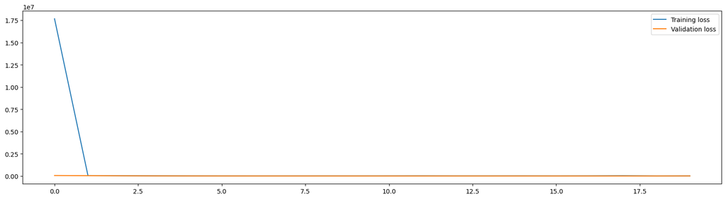

```python
# 3 ukryte neurony

# Mniej przetworzony zbiór
model = Sequential([
    Dense(17, activation='relu', input_shape=(16,)),
    Dense(3, activation='relu'),
    Dense(1)
])
model.compile(optimizer='adam', loss='mse')

history = model.fit(x1_train, y1_train, validation_data=(x1_test, y1_test), epochs=20)
y1_pred = model.predict(x1_test)
accuracy = accuracy_score(y1_test, y1_pred.round())
print("Dokładność 3 ukrytych neuronów 1: {:.2f}".format(accuracy))
print(confusion_matrix(y1_test, y1_pred.round()))
acc1.append(accuracy)
plt.plot(history.history['loss'], label='Training loss')
plt.plot(history.history['val_loss'], label='Validation loss')
plt.legend()
plt.show()
```

```
Dokładność 3 ukrytych neuronów 2: 0.19
[[   0    0   19  212  395  477  233   24    0    0]
 [   0    0   59  765  423  127   14    1    0    0]
 [   0    0   32  309  482  472   66    2    0    0]
 [   0    0    8 1036  178   49    0    0    0    0]
 [   0    0    6  113  450  567  177    8    0    0]
 [   0    0   13  298  475  346  139   12    0    0]
 [   0    0    0    5   42  294  727  304    3    0]
 [   0    0    2  160  425  622  131   16    0    0]
 [   0    0    1   13   70  301  663  276    0    0]
 [   0    0    2  106  360  542  303   23    0    0]]
```

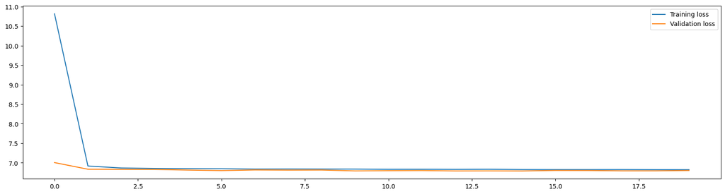

```python
model = Sequential([
    Dense(17, activation='relu', input_shape=(2,)),
    Dense(3, activation='relu'),
    Dense(1)
])
model.compile(optimizer='adam', loss='mse')

history = model.fit(x2_train, y2_train, validation_data=(x2_test, y2_test), epochs=20)
y2_pred = model.predict(x2_test)
accuracy = accuracy_score(y2_test, y2_pred.round())
print("Dokładność 3 ukrytych neuronów 2: {:.2f}".format(accuracy))
print(confusion_matrix(y2_test, y2_pred.round()))
acc2.append(accuracy)
plt.plot(history.history['loss'], label='Training loss')
plt.plot(history.history['val_loss'], label='Validation loss')
plt.legend()
plt.show()
```

```
Dokładność 8, 4 ukrytych neuronów 1: 0.10
[[   0    0    0    0 1360    0    0    0    0    0]
 [   0    0    0    0 1389    0    0    0    0    0]
 [   0    0    0    0 1363    0    0    0    0    0]
 [   0    0    0    0 1271    0    0    0    0    0]
 [   0    0    0    0 1321    0    0    0    0    0]
 [   0    0    0    0 1283    0    0    0    0    0]
 [   0    0    0    0 1375    0    0    0    0    0]
 [   0    0    0    0 1356    0    0    0    0    0]
 [   0    0    0    0 1324    0    0    0    0    0]
 [   0    0    0    0 1336    0    0    0    0    0]]
```

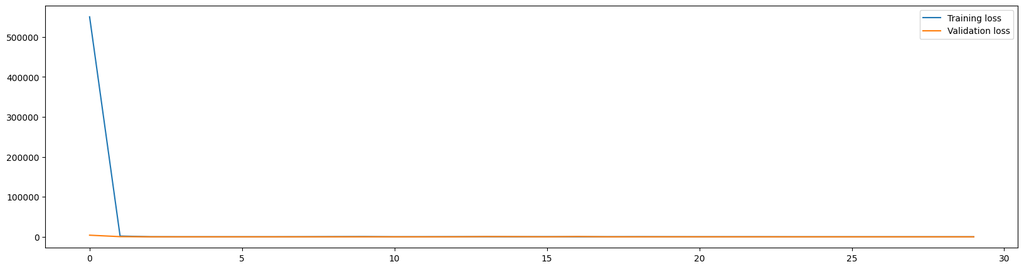

```python
# 8, 4 ukryte neurony

# Mniej przetworzony zbiór
model = Sequential([
    Dense(17, activation='relu', input_shape=(16,)),
    Dense(8, activation='relu'),
    Dense(4, activation='relu'),
    Dense(1)
])
model.compile(optimizer='adam', loss='mse')

history = model.fit(x1_train, y1_train, validation_data=(x1_test, y1_test), epochs=30)
y1_pred = model.predict(x1_test)
accuracy = accuracy_score(y1_test, y1_pred.round())
print("Dokładność 8, 4 ukrytych neuronów 1: {:.2f}".format(accuracy))
print(confusion_matrix(y1_test, y1_pred.round()))
acc1.append(accuracy)
plt.plot(history.history['loss'], label='Training loss')
plt.plot(history.history['val_loss'], label='Validation loss')
plt.legend()
plt.show()
```

```
Dokładność 8, 4 ukrytych neuronów 2: 0.19
[[   0    0   50  260  404  384  237   25    0    0]
 [   0    0  169  762  355   92   10    1    0    0]
 [   0    0   84  354  472  374   77    2    0    0]
 [   0    0   23 1045  156   47    0    0    0    0]
 [   0    0   24  163  472  483  170    9    0    0]
 [   0    0   64  334  470  267  137   11    0    0]
 [   0    0    1    9   63  262  723  317    0    0]
 [   0    0    6  192  447  533  161   17    0    0]
 [   0    0    2   23   85  271  651  292    0    0]
 [   0    0   15  152  392  470  286   21    0    0]]
```

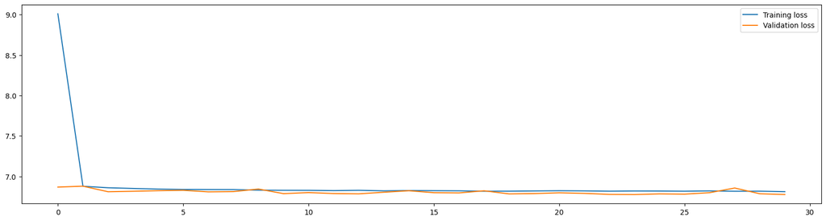

```python
# Bardziej przetworzony zbiór
model = Sequential([
    Dense(17, activation='relu', input_shape=(2,)),
    Dense(8, activation='relu'),
    Dense(4, activation='relu'),
    Dense(1)
])
model.compile(optimizer='adam', loss='mse')

history = model.fit(x2_train, y2_train, validation_data=(x2_test, y2_test), epochs=30)
y2_pred = model.predict(x2_test)
accuracy = accuracy_score(y2_test, y2_pred.round())
print("Dokładność 8, 4 ukrytych neuronów 2: {:.2f}".format(accuracy))
print(confusion_matrix(y2_test, y2_pred.round()))
acc2.append(accuracy)
plt.plot(history.history['loss'], label='Training loss')
plt.plot(history.history['val_loss'], label='Validation loss')
plt.legend()
plt.show()
```

```
Dokładność 3 ukrytych neuronów 1: 0.10
[[   0    0    0    0 1360    0    0    0    0    0]
 [   0    0    0    0 1389    0    0    0    0    0]
 [   0    0    0    0 1363    0    0    0    0    0]
 [   0    0    0    0 1271    0    0    0    0    0]
 [   0    0    0    0 1321    0    0    0    0    0]
 [   0    0    0    0 1283    0    0    0    0    0]
 [   0    0    0    0 1375    0    0    0    0    0]
 [   0    0    0    0 1356    0    0    0    0    0]
 [   0    0    0    0 1324    0    0    0    0    0]
 [   0    0    0    0 1336    0    0    0    0    0]]
```

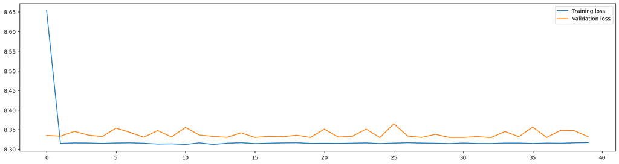

```python
# 3 ukryte neurony

# Mniej przetworzony zbiór
model = Sequential([
    Dense(17, activation='sigmoid', input_shape=(16,)),
    Dense(3, activation='sigmoid'),
    Dense(1)
])
model.compile(optimizer='SGD', loss='mse')

history = model.fit(x1_train, y1_train, validation_data=(x1_test, y1_test), epochs=40)
y1_pred = model.predict(x1_test)
accuracy = accuracy_score(y1_test, y1_pred.round())
print("Dokładność 3 ukrytych neuronów 1: {:.2f}".format(accuracy))
print(confusion_matrix(y1_test, y1_pred.round()))
acc1.append(accuracy)
plt.plot(history.history['loss'], label='Training loss')
plt.plot(history.history['val_loss'], label='Validation loss')
plt.legend()
plt.show()
```

```
Dokładność 3 ukrytych neuronów 2: 0.20
[[   0    0   57  286  391  388  223   15    0    0]
 [   0    0  185  807  304   85    8    0    0    0]
 [   0    0   96  390  434  384   59    0    0    0]
 [   0    0   39 1038  163   31    0    0    0    0]
 [   0    0   27  202  435  505  148    4    0    0]
 [   0    0   76  375  410  290  123    9    0    0]
 [   0    0    0   13   56  304  767  235    0    0]
 [   0    0    5  228  446  526  140   11    0    0]
 [   0    0    3   29   82  322  679  209    0    0]
 [   0    0   21  173  369  504  261    8    0    0]]
```

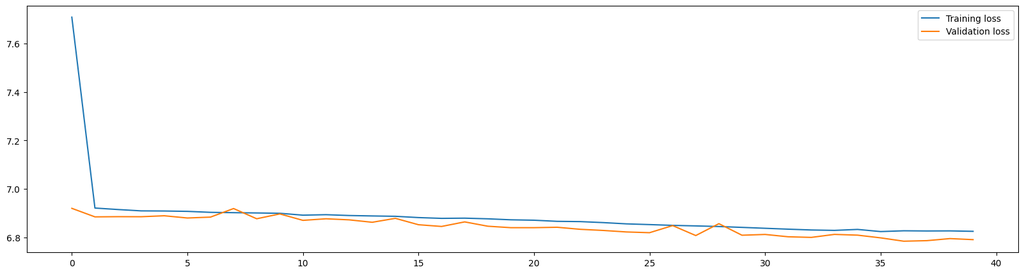

```python
# Bardziej przetworzony zbiór
model = Sequential([
    Dense(17, activation='sigmoid', input_shape=(2,)),
    Dense(3, activation='sigmoid'),
    Dense(1)
])
model.compile(optimizer='SGD', loss='mse')

history = model.fit(x2_train, y2_train, validation_data=(x2_test, y2_test), epochs=40)
y2_pred = model.predict(x2_test)
accuracy = accuracy_score(y2_test, y2_pred.round())
print("Dokładność 3 ukrytych neuronów 2: {:.2f}".format(accuracy))
print(confusion_matrix(y2_test, y2_pred.round()))
acc2.append(accuracy)
plt.plot(history.history['loss'], label='Training loss')
plt.plot(history.history['val_loss'], label='Validation loss')
plt.legend()
plt.show()
```

## 4. Podsumowanie

```python
headers = ['Przycięte drzewo decyzycjne', 'Pełne drzewo decyzyjne', 'Naiwny Bayes', 'k=5', 'k=50', 'k=500', '3 ukryte neurony', '8, 4 ukryte neurony', '3 ukryte neurony sigmoid']
table = tabulate.tabulate([acc1, acc2], headers, tablefmt='orgtbl')
print(table)
```

```
|   Przycięte drzewo decyzycjne |   Pełne drzewo decyzyjne |   Naiwny Bayes |      k=5 |     k=50 |    k=500 |   3 ukryte neurony |   8, 4 ukryte neurony |   3 ukryte neurony sigmoid |
|-------------------------------+--------------------------+----------------+----------+----------+----------+--------------------+-----------------------+----------------------------|
|                      0.443938 |                 0.441247 |       0.380401 | 0.125878 | 0.145014 | 0.155255 |        0.000747496 |             0.0987442 |                  0.0987442 |
|                      0.30595  |                 0.227089 |       0.300194 | 0.257886 | 0.299297 | 0.310136 |        0.194872    |             0.194947  |                  0.197115  |
```

Projekt polegał na porównaniu wyników klasyfikacji różnych algorytmów i architektur sieci neuronowych na zbiorze danych.

Wyniki klasyfikacji zostały przedstawione w tabeli, która zawiera wyniki dla przyciętego i pełnego drzewa decyzyjnego, algorytmu Naiwnego Bayesa, sieci neuronowych z różną liczbą neuronów oraz klasyfikatora N-najbliższych sąsiadów.

Najgorszy wynik został osiągnięty dla sieci z 3 ukrytymi neuronami i mniej przetworzonego zbioru z wynikiem 0.000747496 (0%).

Zwiększenie liczby neuronów w sieci neuronowej miało pozytywny wpływ na wynik klasyfikacji, jednak zwiększenie wartości parametru k przy najbliższych sąsiadach nie miało dużego wpływu na wynik. Oznacza to, że zwiększenie liczby neuronów w sieci neuronowej może być skuteczną metodą poprawy wyniku klasyfikacji, ale zwiększenie wartości parametru k może nie przynieść dużych korzyści.

Podsumowując, wyniki projektu pokazały, że przycięte drzewo decyzyjne jest najlepszym algorytmem do klasyfikacji tego zbioru danych. Wynik ten może być zaskakujący, ponieważ drzewa decyzyjne są często uważane za mniej skuteczne niż bardziej zaawansowane algorytmy uczenia maszynowego, takie jak sieci neuronowe. Może to wynikać jednak z faktu, iż powyższe sieci są mało skomplikowane i posiadają niewiele iteracji.

W porównaniu bardziej i mniej przetworzonego zbioru danych, mniej obrobione dane lepiej sprawdzają się w przypadku drzew decyzyjnych i klasyfikatora Naive-Bayes, zaś wypadają gorzej przy sieciach neuronowych i klasyfikatorze k-Najbliższych Sąsiadów.

## 5. Bibliografia

- https://www.kaggle.com/datasets/vicsuperman/prediction-of-music-genre?resource=download
- https://www.kaggle.com/code/zetahaxx/accuracy-0-82326-music-genre-prediction
- https://www.geeksforgeeks.org/principal-component-analysis-with-python/
- https://scikit-learn.org/stable/index.html